# Homework2

Kathleen Cimino

2/21/2022

The data set utilized for this set of questions studies the remission survival times on 42 leukemia patients, half of whom get a certain new treatment therapy and the other half of whom get a standard treatment therapy. The exposure variable of interest is treatment status (Rx = 0 if new treatment, Rx = 1 if standard treatment). Two other variables for control as potential confounders are log white blood cell count (i.e., logwbc) and sex. Event status is defined by the relapse variable (0 if censored, 1 if relapse). (The data set is available online and can be imported with the following code).

```r
#Import anderson data file
anderson<-read.delim("https://raw.githubusercontent.com/nazzstat/SurvivalData/master/ander", header=TRUE)

#Add in column names
names(anderson)<-c("survtime","relapse","sex","logwbc","rx")
```

1. Suppose we wish to describe KM curves for the variable logwbc in order for us to understand whether white blood count relates to survival time. Suppose we categorize logwbc into three categories - low (0–2.30), medium (2.31–3.00), and high (>3.00). State your conclusions based on your visual assessment of the KM curves.

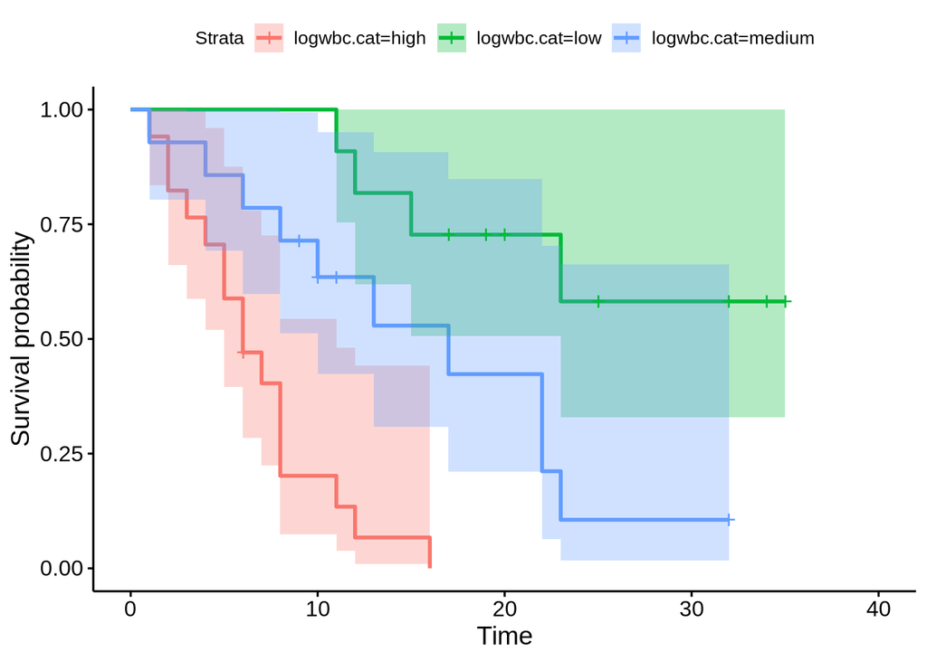

```r
anderson <- anderson %>%
  mutate(logwbc.cat=ifelse(logwbc<2.31,"low",
                           ifelse(logwbc>3,"high",
                                  ifelse(logwbc>2.3,"medium","error"))))
model1 <- survfit(Surv(survtime,relapse)~logwbc.cat, data=anderson)
ggsurvplot(model1, conf.int=TRUE)
```

Visually, the survival curves of the high and low categories are different, with no overlap in the 95% CIs. The survival curves of the low category compared to the medium category and the high category compared to the medium category are visually different, but there is some overlap in the 95% CIs (with the overlap between the medium and high categories being most noticeable).

2. What do you conclude about whether or not the three survival curves vary significantly.

```r
survdiff(Surv(survtime,relapse)~logwbc.cat, data=anderson, rho=0)
```

```
## Call:
## survdiff(formula = Surv(survtime, relapse) ~ logwbc.cat, data = anderson,
##     rho = 0)
##
##                    N Observed Expected (O-E)^2/E (O-E)^2/V
## logwbc.cat=high   17       16     6.21   15.4173   23.1040
## logwbc.cat=low    11        4    13.06    6.2880   12.7695
## logwbc.cat=medium 14       10    10.72    0.0489    0.0809
##
##  Chisq= 26.4  on 2 degrees of freedom, p= 2e-06
```

2. Next consider the data set std available through the KMsurv package. This data considers times to reinfection for patients with sexually transmitted diseases. Under investigation are gonorrhea and chlamydia. These diseases are of special interest because they are often asymptomatic in the female, and, if left untreated, can lead to complications including sterility. Both of these diseases can be easily prevented and effectively treated. Therefore, it is a mystery why the incidence of these diseases remain high in several sub populations. One theory is that a core group of individuals experience reinfections. thereby, serving as a natural reservoir of the disease organism and transferring the disease to uninfected individuals. The purpose of this study is to identify the factors which are related to time until reinfection. If the factors related to a greater risk of reinfection can be identified, then, interventions could be targeted to those individuals who are at the greatest risk for reinfection. We will explore this data set more in a future homework assignment.

```r
data(std)
```

1. Construct the KM survival curves to compare the risk of reinfection for participants who always use condoms versus those who do not always use condoms (that is, clump together the sometimes and never participants into one category).

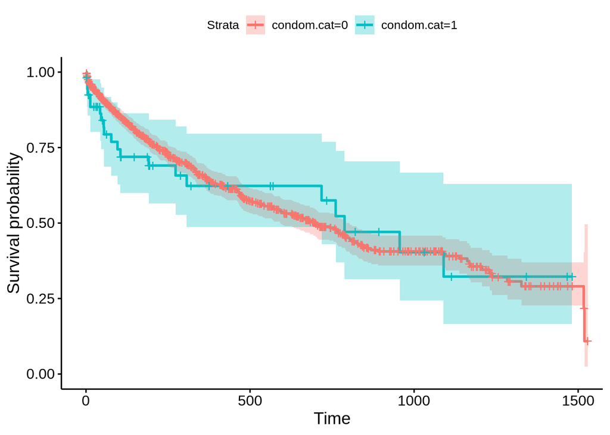

```r
std <- std %>% mutate(condom.cat=ifelse(condom==1, 1, 0))
model2a <- survfit(Surv(time,rinfct)~condom.cat, data=std)
ggsurvplot(model2a, conf.int=TRUE)
```

2. Is there is a significant difference in the survival curves between the two groups above?

```r
survdiff(Surv(time,rinfct)~condom.cat, data=std, rho=0)
```

```
## Call:
## survdiff(formula = Surv(time, rinfct) ~ condom.cat, data = std,
##     rho = 0)
##
##                N Observed Expected (O-E)^2/E (O-E)^2/V
## condom.cat=0 823      326    327.7   0.00907     0.164
## condom.cat=1  54       21     19.3   0.15427     0.164
##
##  Chisq= 0.2  on 1 degrees of freedom, p= 0.7
```

There is not a statistically significant difference between those who always use condoms and those who don’t ($\chi^2$=.2, p-value=0.7)

3. Construct and interpret a 95% confidence interval to compare the median survival time of participants who always wear condoms versus those who do not.

```r
model2a
```

```
## Call: survfit(formula = Surv(time, rinfct) ~ condom.cat, data = std)
##
##                n events median 0.95LCL 0.95UCL
## condom.cat=0 823    326    698     592     803
## condom.cat=1  54     21    788     307      NA
```

The median survival time for those who do not always wear a condom is 698 units of time (CI: 592-803). Approximately half of the participants go without reinfection for at least 698 units of time, with a lower bound of the expected real population not being reinfected of 592 units of time, and an upper bound of 803 units of time.

The median survival time for those who do always wear a condom is 788 units of time (CI: 307-NA, there is no upper bound on the 95% CI). Approximately half of the participants go without reinfection for at least 788 units of time, with a lower bound of the expected real population not being reinfected of 307 units of time, and an infinite upper bound where enough patients were not reinfected during the study it is difficult to determine an upper limit on the 95% Confidence Interval.

4. What can be said about the probability that someone from the population of interest (for those who always wear condoms versus those who do not) will not be reinfected after 1 year?

```r
options(max.print=10000000)
summary(model2a)
```

[output not shown]

The 95% Confidence interval for the proportion of people who do not always wear a condom who will survive past 367 days (the closest data we have to 365 days) is 0.607 - 0.683. This indicates that the probability of surviving past 367 days is .644 and we are 95% confident that between 60.7 and 68.3 percent of the population will survive beyond 367 days.

The 95% Confidence interval for the proportion of people who always wear a condom who will survive past 307 days (the closest data we have to 365 days) is 0.487 - 0.796. This indicates that the probability of surviving past 307 days is .623 and we are 95% confident that between 48.7 and 79.6 percent of the population will survive beyond 307 days.

5. Construct a model to determine what factors are significantly associated with a participant’s risk of reinfection. Consider the variables npartner, os12m, rs12m, condom. Give a description of your findings.

```r
mod2e<- coxph(Surv(time,rinfct) ~ npartner+ os12m +rs12m + factor(condom), data=std)
summary(mod2e)
```

```
## Call:
## coxph(formula = Surv(time, rinfct) ~ npartner + os12m + rs12m +
##     factor(condom), data = std)
##
##   n= 877, number of events= 347
##
##                     coef exp(coef) se(coef)      z Pr(>|z|)
## npartner         0.09839   1.10339  0.04862  2.024    0.043 *
## os12m           -0.60981   0.54346  0.13692 -4.454 8.44e-06 ***
## rs12m           -0.08015   0.92298  0.27776 -0.289    0.773
## factor(condom)2 -0.01415   0.98595  0.22948 -0.062    0.951
## factor(condom)3 -0.29832   0.74207  0.23795 -1.254    0.210
## ---
## Signif. codes:  0 '***' 0.001 '**' 0.01 '*' 0.05 '.' 0.1 ' ' 1
##
##                 exp(coef) exp(-coef) lower .95 upper .95
## npartner           1.1034     0.9063    1.0031    1.2137
## os12m              0.5435     1.8401    0.4155    0.7107
## rs12m              0.9230     1.0835    0.5355    1.5908
## factor(condom)2    0.9859     1.0143    0.6288    1.5459
## factor(condom)3    0.7421     1.3476    0.4655    1.1830
##
## Concordance= 0.594  (se = 0.017 )
## Likelihood ratio test= 33.41  on 5 df,   p=3e-06
## Wald test            = 30.92  on 5 df,   p=1e-05
## Score (logrank) test = 31.6  on 5 df,   p=7e-06
```

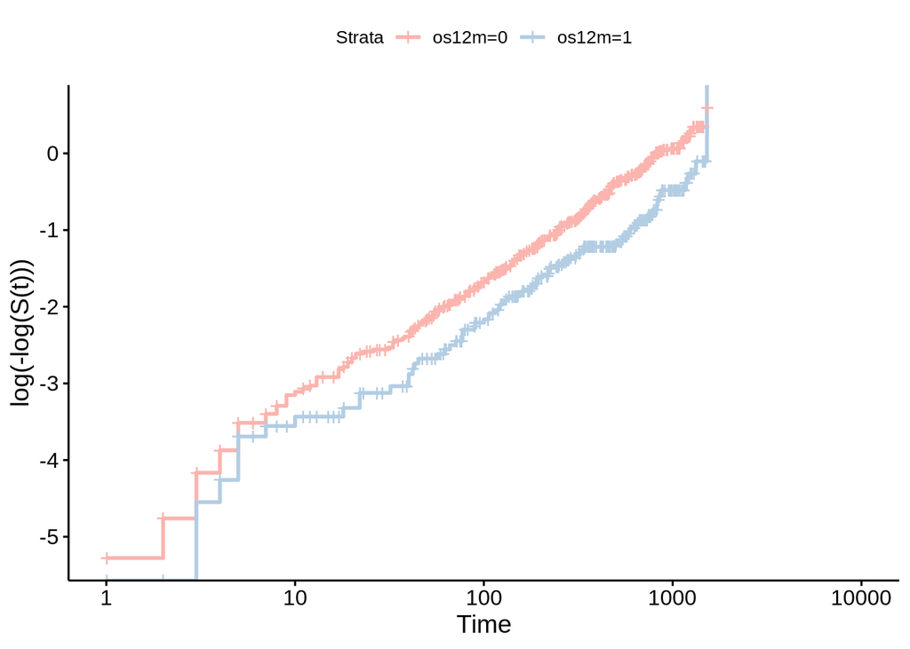

```r
myfit2eo<- survfit(Surv(time,rinfct) ~ os12m, data=std)
ggsurvplot(myfit2eo, conf.int="FALSE", fun="cloglog", data=std, palette="Pastel1")
```

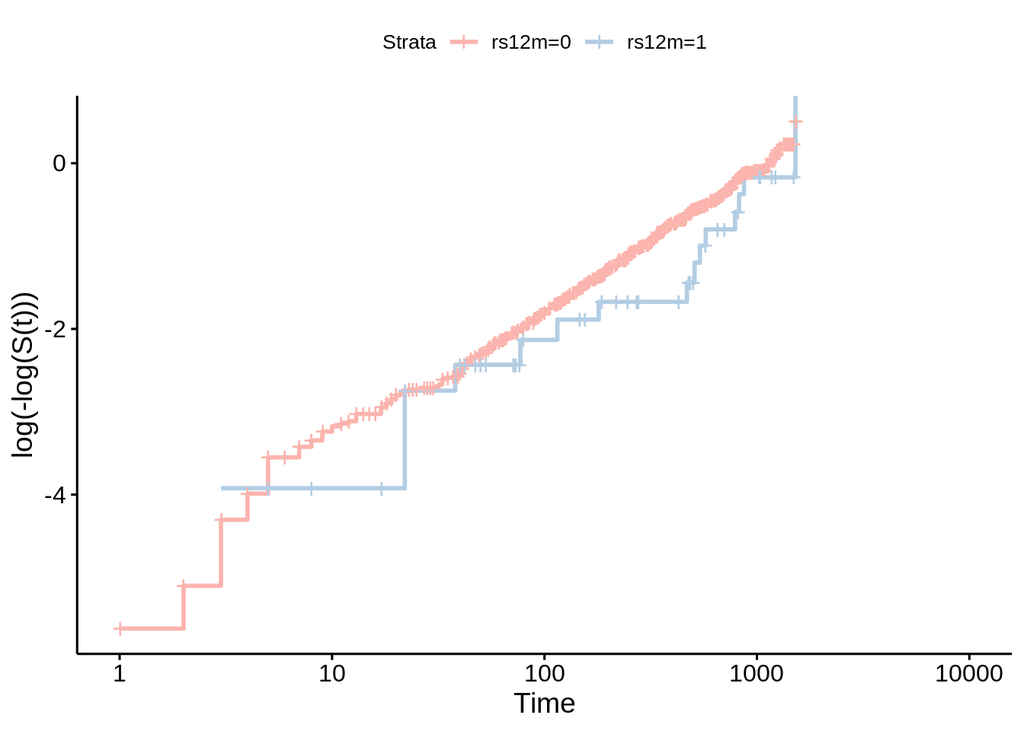

```r
myfit2er<- survfit(Surv(time,rinfct) ~ rs12m, data=std)
ggsurvplot(myfit2er, conf.int="FALSE", fun="cloglog", data=std, palette="Pastel1") # no good
```

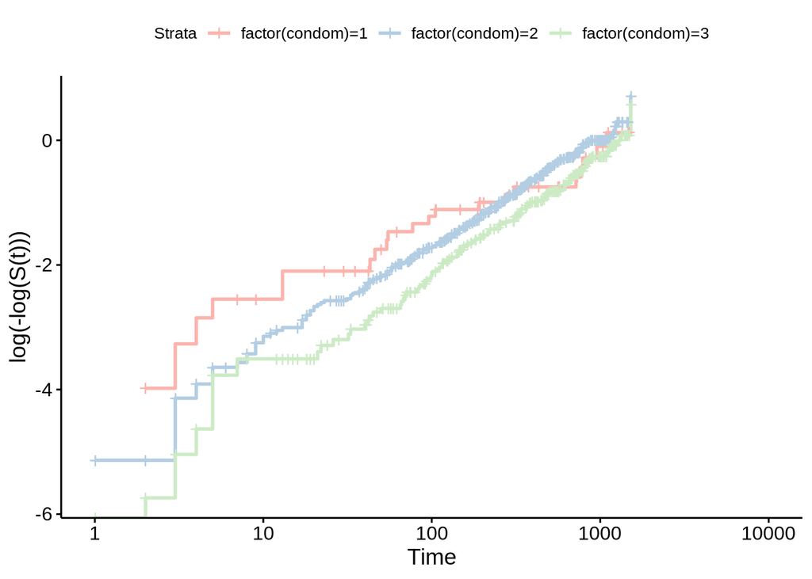

```r
myfit2ec<- survfit(Surv(time,rinfct) ~factor(condom), data=std)
ggsurvplot(myfit2ec, conf.int="FALSE", fun="cloglog", data=std, palette="Pastel1")
```

```r
cox.zph(mod2e, transform="rank")
```

```
##                 chisq df    p
## npartner       0.1274  1 0.72
## os12m          0.0905  1 0.76
## rs12m          0.3626  1 0.55
## factor(condom) 2.8977  2 0.23
## GLOBAL         3.5582  5 0.61
```

Visually, os12m does have an area near the beginning that is a little concerning, but it seems to not egregiously violate the PH. Condom similarly has an area near the end where condom 1 suddenly gets much closer to condom 2 and condom 3, but it seems to achieve good enough parallelism. rs12m, however, appears to violate the PH because rs12m 1 gets closer and then further from rs12m in two different areas. This could potentially be due to sample size, and therefore might be best ignored. There are no statistically significant violations.

Trying subsetting the data to account for the potential violation of rs12m

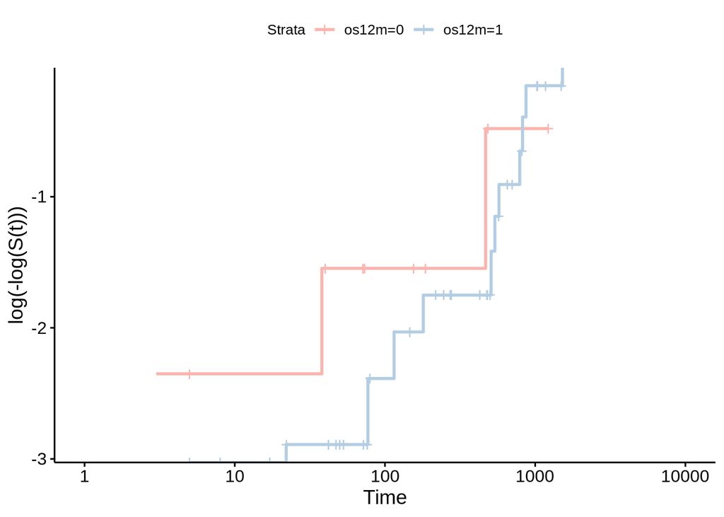

```r
std1 <- filter(std, rs12m ==1)
std2 <- filter(std, rs12m ==0)
myfit2eo1<- survfit(Surv(time,rinfct) ~ os12m, data=std1)
ggsurvplot(myfit2eo1, conf.int="FALSE", fun="cloglog", data=std1, palette="Pastel1")
```

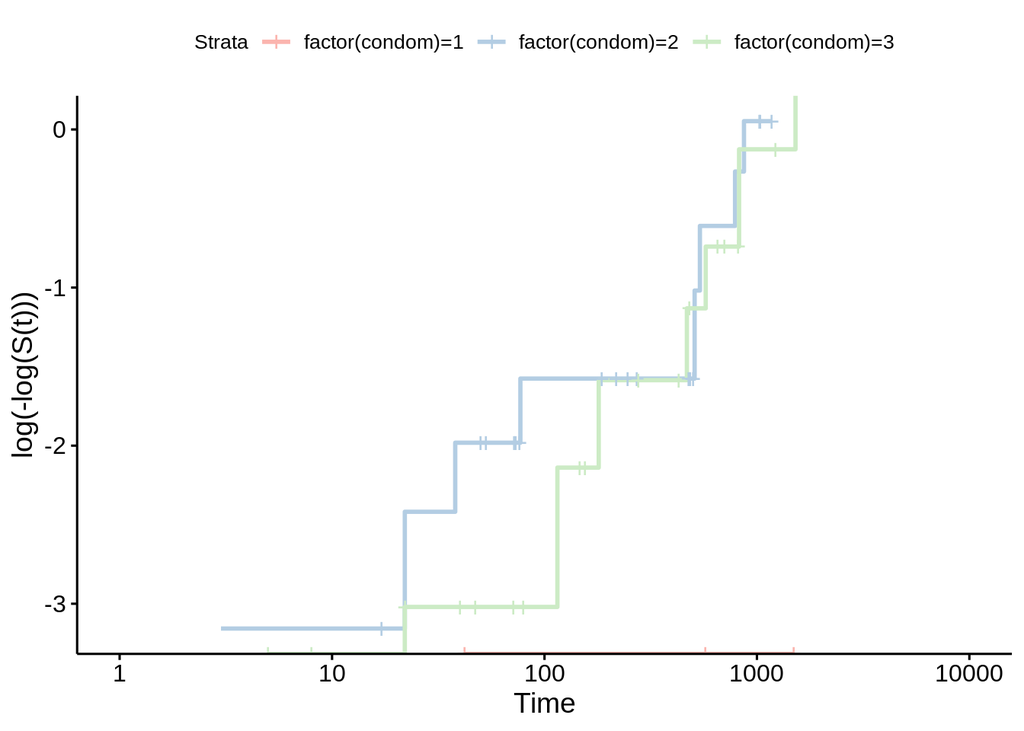

```r
myfit2ec1<- survfit(Surv(time,rinfct) ~factor(condom), data=std1)
ggsurvplot(myfit2ec1, conf.int="FALSE", fun="cloglog", data=std1, palette="Pastel1")
```

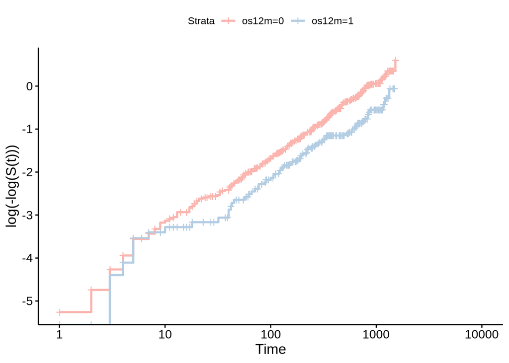

```r
myfit2eo2<- survfit(Surv(time,rinfct) ~ os12m, data=std2)
ggsurvplot(myfit2eo2, conf.int="FALSE", fun="cloglog", data=std2, palette="Pastel1")
```

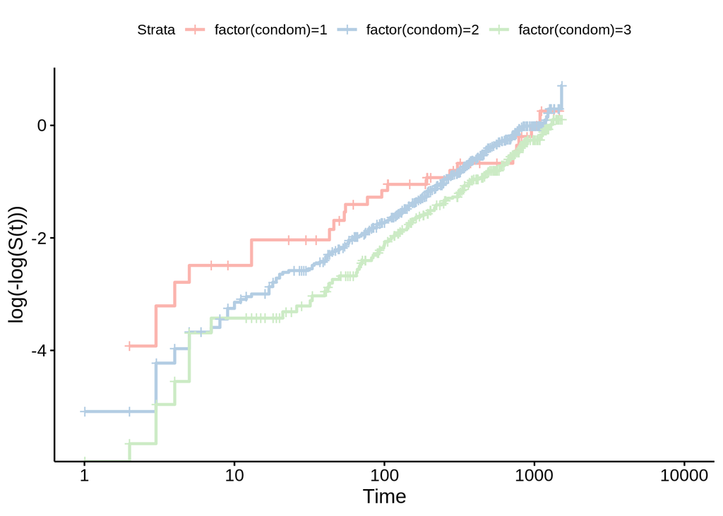

```r
myfit2ec2<- survfit(Surv(time,rinfct) ~factor(condom), data=std2)
ggsurvplot(myfit2ec2, conf.int="FALSE", fun="cloglog", data=std2, palette="Pastel1")
```

After dividing by rs12m, all of the curves for rs12m 0 seem to achieve parallelism, while both of the curves for rs12m 1 do not appear to. This is likely due to the smaller sample size of rs12m 1, and so it is likely better to not control for rs12m and just say it achieves close enough parallelism.

```r
summary(mod2e)
```

```
## Call:
## coxph(formula = Surv(time, rinfct) ~ npartner + os12m + rs12m +
##     factor(condom), data = std)
##
##   n= 877, number of events= 347
##
##                     coef exp(coef) se(coef)      z Pr(>|z|)
## npartner         0.09839   1.10339  0.04862  2.024    0.043 *
## os12m           -0.60981   0.54346  0.13692 -4.454 8.44e-06 ***
## rs12m           -0.08015   0.92298  0.27776 -0.289    0.773
## factor(condom)2 -0.01415   0.98595  0.22948 -0.062    0.951
## factor(condom)3 -0.29832   0.74207  0.23795 -1.254    0.210
## ---
## Signif. codes:  0 '***' 0.001 '**' 0.01 '*' 0.05 '.' 0.1 ' ' 1
##
##                 exp(coef) exp(-coef) lower .95 upper .95
## npartner           1.1034     0.9063    1.0031    1.2137
## os12m              0.5435     1.8401    0.4155    0.7107
## rs12m              0.9230     1.0835    0.5355    1.5908
## factor(condom)2    0.9859     1.0143    0.6288    1.5459
## factor(condom)3    0.7421     1.3476    0.4655    1.1830
##
## Concordance= 0.594  (se = 0.017 )
## Likelihood ratio test= 33.41  on 5 df,   p=3e-06
## Wald test            = 30.92  on 5 df,   p=1e-05
## Score (logrank) test = 31.6  on 5 df,   p=7e-06
```

6. As the number of a participant’s sexual partners increases by 1, what exactly can be said about the instantaneous hazard of reinfection?

As the number of a participant’s sexual partners increases by 1, the expected hazards increases by a factor of 1.10.

3. Complete and submit the Exercises to Try at the end of the Topic 3C notes.
4. Consider the data set ‘bfeed’ available through the `KMsurv’ package. It is also available through the github url. The data consists of the information from 927 first-born children to mothers who chose to breastfeed their children and who have complete information for all variables of interest. The number of weeks until infant was weaned (duration) was recorded and whether or not weaning completed during study period was also recorded (delta). There are several covariates that are also available.

```r
library(survival)
library(KMsurv)
#?bfeed
bfeed<-read.csv("https://raw.githubusercontent.com/nazzstat/SurvivalData/master/bfeed.csv")
```

1. Determine whether poverty level and race are significant predictors of hazard of weaning using a Cox PH model.

```r
mod1a<- coxph(Surv(duration, delta) ~ poverty+factor(race), data=bfeed)
summary(mod1a)
```

```
## Call:
## coxph(formula = Surv(duration, delta) ~ poverty + factor(race),
##     data = bfeed)
##
##   n= 927, number of events= 892
##
##                   coef exp(coef) se(coef)      z Pr(>|z|)
## poverty       -0.10985   0.89597  0.08723 -1.259  0.20790
## factor(race)2  0.12734   1.13580  0.10317  1.234  0.21710
## factor(race)3  0.26822   1.30763  0.09309  2.881  0.00396 **
## ---
## Signif. codes:  0 '***' 0.001 '**' 0.01 '*' 0.05 '.' 0.1 ' ' 1
##
##               exp(coef) exp(-coef) lower .95 upper .95
## poverty           0.896     1.1161    0.7552     1.063
## factor(race)2     1.136     0.8804    0.9279     1.390
## factor(race)3     1.308     0.7647    1.0895     1.569
##
## Concordance= 0.527  (se = 0.01 )
## Likelihood ratio test= 9.25  on 3 df,   p=0.03
## Wald test            = 9.58  on 3 df,   p=0.02
## Score (logrank) test = 9.62  on 3 df,   p=0.02
```

Poverty is not significant (z=-1.259, p=.2) and neither is being black (z=1.234, p-value=.22), but being a race other than black or white is statistically significant (z=2.88, p-value=.004)

2. Assess the PH assumption of poverty level graphically.

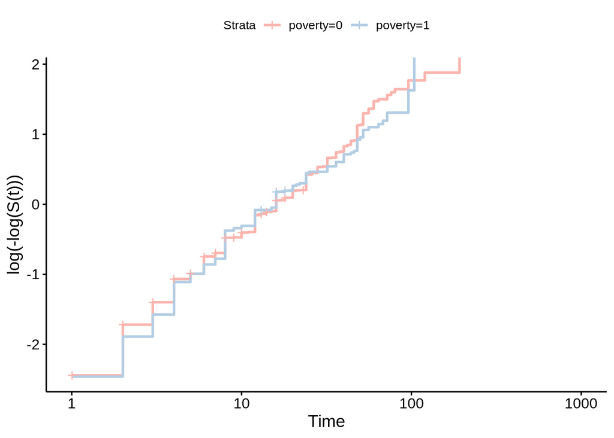

```r
myfit1b<- survfit(Surv(duration, delta) ~ poverty, data=bfeed)
ggsurvplot(myfit1b, conf.int="FALSE", fun="cloglog", data=bfeed, palette="Pastel1")
```

Proportional Hazards Assumption seems reasonable since there is approximate parallelism in -log(-logS(t))), although there is some cause for concern near the very end of the graph with the distance between the two lines noticeably widening.

3. Assess the PH assumption of race graphically.

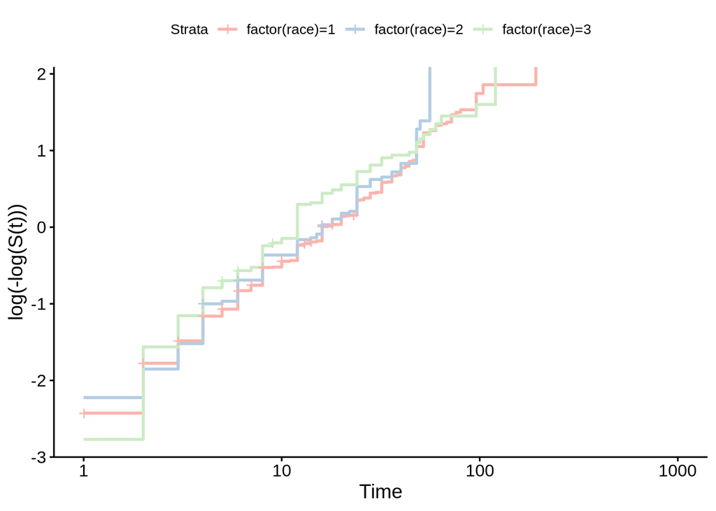

```r
myfit1c<- survfit(Surv(duration, delta) ~ factor(race), data=bfeed)
ggsurvplot(myfit1c, conf.int="FALSE", fun="cloglog", data=bfeed, palette="Pastel1")
```

The PH seems to be okay, as there is a noticeable increase and then decrease in the distance between the curve for mothers who are not white or black compared to the curves for white mothers and black mothers, but this occurs in a relatively small area of the graph and the curves are mostly parallel aside from that.

4. Assess the PH assumptions of both variables via goodness of t tests.

```r
cox.zph(mod1a, transform="rank")
```

```
##              chisq df    p
## poverty       1.60  1 0.21
## factor(race)  2.14  2 0.34
## GLOBAL        3.59  3 0.31
```

Poverty and race do not have significant violations of the PH assumption ($\chi^2_{(1)}$=1.6, p-value=.21; $\chi^2_{(2)}$=2.14, p-value=.34).

5. If your model did not violate the PH assumption, interpret the coefficients of your model.

```r
summary(mod1a)
```

```
## Call:
## coxph(formula = Surv(duration, delta) ~ poverty + factor(race),
##     data = bfeed)
##
##   n= 927, number of events= 892
##
##                   coef exp(coef) se(coef)      z Pr(>|z|)
## poverty       -0.10985   0.89597  0.08723 -1.259  0.20790
## factor(race)2  0.12734   1.13580  0.10317  1.234  0.21710
## factor(race)3  0.26822   1.30763  0.09309  2.881  0.00396 **
## ---
## Signif. codes:  0 '***' 0.001 '**' 0.01 '*' 0.05 '.' 0.1 ' ' 1
##
##               exp(coef) exp(-coef) lower .95 upper .95
## poverty           0.896     1.1161    0.7552     1.063
## factor(race)2     1.136     0.8804    0.9279     1.390
## factor(race)3     1.308     0.7647    1.0895     1.569
##
## Concordance= 0.527  (se = 0.01 )
## Likelihood ratio test= 9.25  on 3 df,   p=0.03
## Wald test            = 9.58  on 3 df,   p=0.02
## Score (logrank) test = 9.62  on 3 df,   p=0.02
```

6. If your model did violate the PH assumption, implement an appropriate solution and interpret your findings.

N/A

2. Consider the data set `burn infection’ available through the github url. The study began to evaluate a protocol change in disinfectant practices for patient’s treated with severe burns. Control of infection remains a prominent component of burn management. The purpose of this study is to compare a routine bathing care method (initial surface decontamination with 10% povidone-iodine followed with regular bathing with Dial soap) with a body-cleansing method using 4% chlorhexidine gluconate. Medical records of patients treated during the 18-month study period provided information on burn wound infections and other medical information.

```r
burn_infection<-read.csv("https://raw.githubusercontent.com/nazzstat/SurvivalData/master/burn_infection.csv")
```

- Z1: Treatment (0=routine bathing, 1=body cleansing)
- Z2: Gender (0=male, 1=female)
- Z3: Burn Type (1=chemical, 2=scald, 3=electric, 4= ame)
- T1: Time to infection or censorship
- D1: Infection (1=yes, 0=no)
1. Construct a model that assesses the relationship of hazards of based on the variables treatment, gender, and burn type.

```r
mod2a<- coxph(Surv(T1, D1) ~ Z1+Z2+factor(Z3), data=burn_infection)
summary(mod2a)
```

```
## Call:
## coxph(formula = Surv(T1, D1) ~ Z1 + Z2 + factor(Z3), data = burn_infection)
##
##   n= 154, number of events= 99
##
##                coef exp(coef) se(coef)      z Pr(>|z|)
## Z1           0.6773    1.9685   0.2368  2.860  0.00424 **
## Z2           0.5570    1.7454   0.2106  2.644  0.00819 **
## factor(Z3)2 -0.7908    0.4535   0.5034 -1.571  0.11619
## factor(Z3)3 -1.3418    0.2614   0.8143 -1.648  0.09939 .
## factor(Z3)4 -0.2133    0.8079   0.4030 -0.529  0.59663
## ---
## Signif. codes:  0 '***' 0.001 '**' 0.01 '*' 0.05 '.' 0.1 ' ' 1
##
##             exp(coef) exp(-coef) lower .95 upper .95
## Z1             1.9685     0.5080   1.23750     3.131
## Z2             1.7454     0.5729   1.15505     2.637
## factor(Z3)2    0.4535     2.2051   0.16908     1.216
## factor(Z3)3    0.2614     3.8261   0.05298     1.289
## factor(Z3)4    0.8079     1.2377   0.36675     1.780
##
## Concordance= 0.642  (se = 0.03 )
## Likelihood ratio test= 22.88  on 5 df,   p=4e-04
## Wald test            = 21.7  on 5 df,   p=6e-04
## Score (logrank) test = 22.9  on 5 df,   p=4e-04
```

2. Assess the PH assumption of gender graphically.

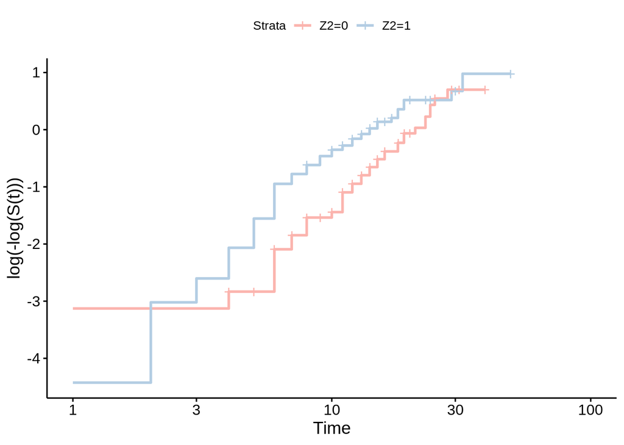

```r
myfit2b<- survfit(Surv(T1, D1) ~ Z2, data=burn_infection)
ggsurvplot(myfit2b, conf.int="FALSE", fun="cloglog", data=burn_infection, palette="Pastel1")
```

The PH assumption of gender seems to be violated as the two curves start close together, widen, and then get closer again.

3. Assess the PH assumption of burn type graphically.

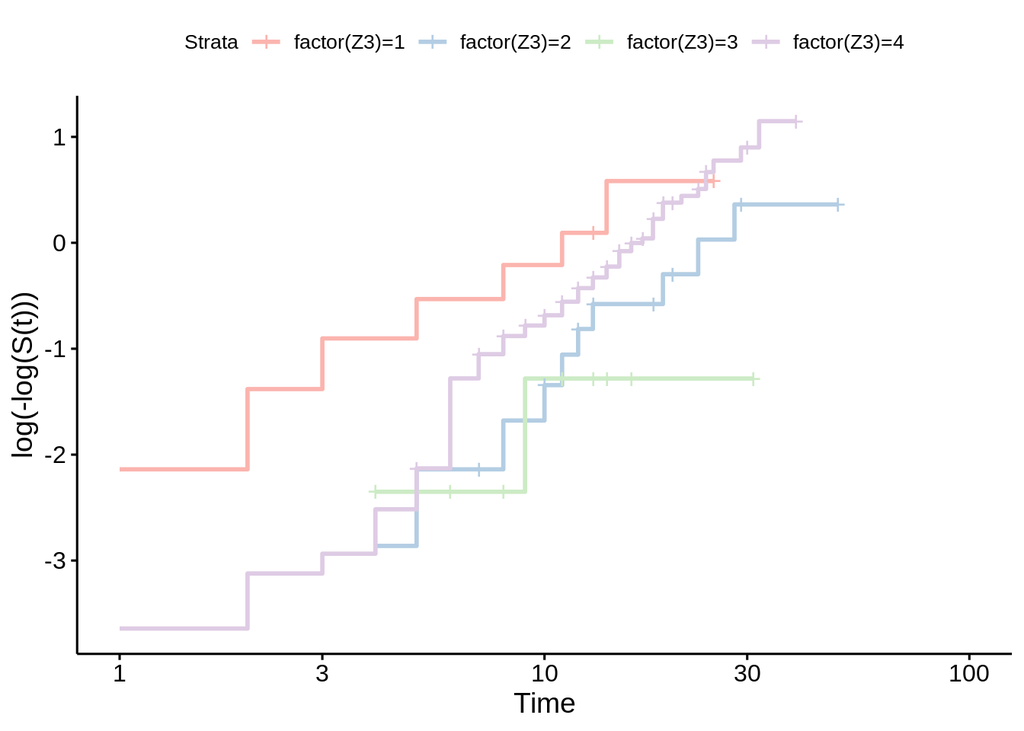

```r
myfit2c<- survfit(Surv(T1, D1) ~ factor(Z3), data=burn_infection)
ggsurvplot(myfit2c, conf.int="FALSE", fun="cloglog", data=burn_infection, palette="Pastel1")
```

While there is potential cause for concern with the electrical burn curve relative to the chemical burn curve, the PH assumptions seem to be mostly okay.

4. Assess the PH assumption of treatment graphically.

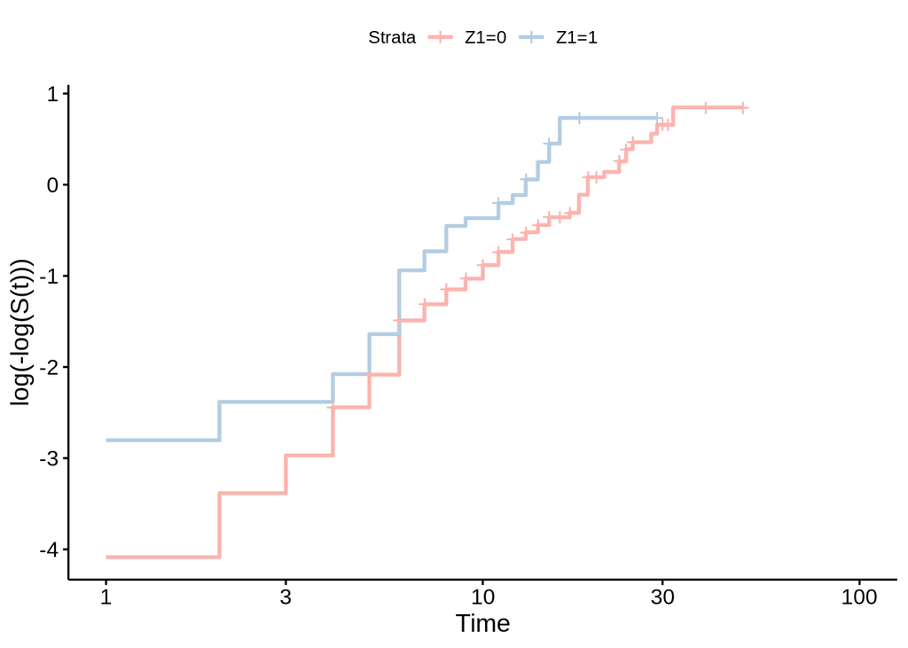

```r
myfit2d<- survfit(Surv(T1, D1) ~ Z1, data=burn_infection)
ggsurvplot(myfit2d, conf.int="FALSE", fun="cloglog", data=burn_infection, palette="Pastel1")
```

There is some cause for concern with the PH assumptions because the curves get close near time 5 and then get further apart, but they seem to be mostly okay.

5. Assess the PH assumptions of all variables via goodness of fit tests.

```r
cox.zph(mod2a, transform="rank")
```

```
##            chisq df    p
## Z1         0.927  1 0.34
## Z2         4.714  1 0.03
## factor(Z3) 2.556  3 0.47
## GLOBAL     8.645  5 0.12
```

The Z2 variable violates the PH assumptions both visually and according to the goodness of fit test.

6. If your model did not violate the PH assumption, interpret the coefficients of your model.
7. If your model did violate the PH assumption, implement an appropriate solution and interpret your findings.

```r
burn_infection_male <- filter(burn_infection, Z2==0)
mod2gm<- coxph(Surv(T1, D1) ~ Z1+factor(Z3), data=burn_infection_male)
cox.zph(mod2gm, transform="rank")
```

```
##             chisq df     p
## Z1         0.0556  1 0.814
## factor(Z3) 7.1111  3 0.068
## GLOBAL     7.7006  4 0.103
```

```r
summary(mod2gm)
```

```
## Call:
## coxph(formula = Surv(T1, D1) ~ Z1 + factor(Z3), data = burn_infection_male)
##
##   n= 70, number of events= 39
##
##                   coef  exp(coef)   se(coef)      z Pr(>|z|)
## Z1           7.774e-01  2.176e+00  3.636e-01  2.138   0.0325 *
## factor(Z3)2 -9.395e-01  3.908e-01  8.704e-01 -1.079   0.2804
## factor(Z3)3 -1.821e+01  1.232e-08  5.210e+03 -0.003   0.9972
## factor(Z3)4  7.944e-02  1.083e+00  7.540e-01  0.105   0.9161
## ---
## Signif. codes:  0 '***' 0.001 '**' 0.01 '*' 0.05 '.' 0.1 ' ' 1
##
##             exp(coef) exp(-coef) lower .95 upper .95
## Z1          2.176e+00  4.596e-01   1.06682     4.437
## factor(Z3)2 3.908e-01  2.559e+00   0.07097     2.152
## factor(Z3)3 1.232e-08  8.119e+07   0.00000       Inf
## factor(Z3)4 1.083e+00  9.236e-01   0.24701     4.746
##
## Concordance= 0.646  (se = 0.046 )
## Likelihood ratio test= 13.39  on 4 df,   p=0.01
## Wald test            = 7.04  on 4 df,   p=0.1
## Score (logrank) test = 10.72  on 4 df,   p=0.03
```

```r
burn_infection_female<- filter(burn_infection, Z2==1)
mod2fm<- coxph(Surv(T1, D1) ~ Z1+factor(Z3), data=burn_infection_female)
cox.zph(mod2fm, transform="rank")
```

```
##            chisq df    p
## Z1          1.38  1 0.24
## factor(Z3)  1.65  3 0.65
## GLOBAL      3.40  4 0.49
```

```r
summary(mod2fm)
```

```
## Call:
## coxph(formula = Surv(T1, D1) ~ Z1 + factor(Z3), data = burn_infection_female)
##
##   n= 84, number of events= 60
##
##                coef exp(coef) se(coef)      z Pr(>|z|)
## Z1           0.5279    1.6954   0.3316  1.592    0.111
## factor(Z3)2 -0.5186    0.5953   0.6679 -0.777    0.437
## factor(Z3)3 -0.9567    0.3842   0.8763 -1.092    0.275
## factor(Z3)4 -0.2330    0.7921   0.5054 -0.461    0.645
##
##             exp(coef) exp(-coef) lower .95 upper .95
## Z1             1.6954     0.5898   0.88509     3.247
## factor(Z3)2    0.5953     1.6797   0.16079     2.204
## factor(Z3)3    0.3842     2.6030   0.06896     2.140
## factor(Z3)4    0.7921     1.2624   0.29420     2.133
##
## Concordance= 0.566  (se = 0.037 )
## Likelihood ratio test= 5.64  on 4 df,   p=0.2
## Wald test            = 5.64  on 4 df,   p=0.2
## Score (logrank) test = 5.94  on 4 df,   p=0.2
```